# Final Report for Intro to Data Science

## Ratings among platforms (exclusives)

```r
platformsIMDb<- platforms %>%
  select(ID, IMDb)
```

```r
platformsExclusive <- merge(platformsExclusive, platformsIMDb, by = "ID", all = T)
platformsExclusive
```

| ID | Netflix | Hulu | PrimeVideo | DisneyP | IMDb |
| --- | --- | --- | --- | --- | --- |
| 1 | 1 | 0 | 0 | 0 | 8.8 |
| 2 | 1 | 0 | 0 | 0 | 8.7 |
| 3 | 1 | 0 | 0 | 0 | 8.5 |
| 4 | 1 | 0 | 0 | 0 | 8.5 |
| 5 | NA | NA | NA | NA | 8.8 |
| 6 | 1 | 0 | 0 | 0 | 8.4 |
| 7 | NA | NA | NA | NA | 8.5 |
| 8 | 1 | 0 | 0 | 0 | 8.4 |
| 9 | 1 | 0 | 0 | 0 | 8.4 |
| 10 | 1 | 0 | 0 | 0 | 8.3 |

[output cut: 990 more lines]

```r
platformsExclusive %>%
  gather(Netflix, Hulu, PrimeVideo, DisneyP, key = "platform", value = "value") %>%
  group_by(platform) %>%
  filter(value == 1) %>%
  summarise(ave_score = mean(IMDb))
```

| platform | ave_score |
| --- | --- |
| DisneyP | 6.401290 |
| Hulu | 6.236461 |
| Netflix | 6.294308 |
| PrimeVideo | 5.584927 |

Comparing these scores to the scores above, we can see that any changes was very small. Prime Video’s average rating went slightly lower when including only exclusives, which in turn is most likely why the other three platform’s ratings went up slightly. But this does give an interesting insight to how Disney+, Hulu, and Netflix compare to each other.

We can see that Disney+ and Netflix have almost the same average rating, in both exclusives and shared movies. However, Disney+ has less than half of a library size compared to Netflix, yet it still competes with Netflix, technically beating it by .1 with their average ratings. And Netflix is able to keep a decent average score even though it’s library size is almost 1500 movies.

## Proportion of target Age for each platform

How much of each age group does each platform target towards?

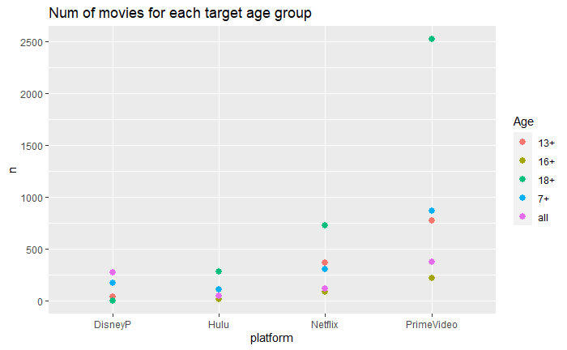

```r
platforms %>%
  gather(Netflix, Hulu, PrimeVideo, DisneyP, key = "platform", value = "value") %>%
  group_by(platform) %>%
  filter(value == 1) %>%
  count(Age) %>%
  ggplot(aes(x = platform, y = n, color = Age)) +
  geom_point(size = 2.5) +
  labs(title = "Num of movies for each target age group")
```

Here we can the distribution of each different age group for each platform. Comparatively, Disney+ has almost an inverse number of movies aimed at 18+ compared to the other three. So you could assume that if you wanted to use a platform that caters to a higher age group then you would pick one of the other three.

## Age of movies on each platform

How recent are the movies on each platform? Would newer platforms such as Disney+ include mostly newer movies?

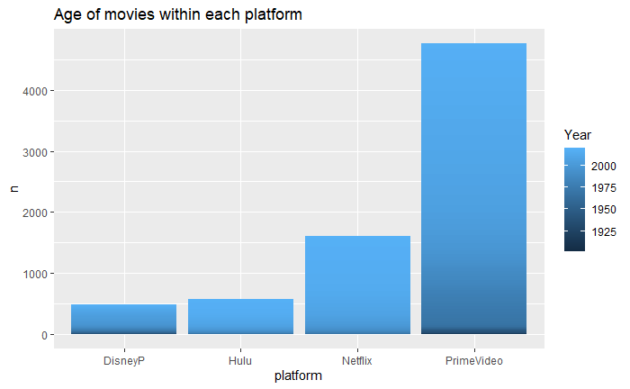

```r
platforms %>%
  gather(Netflix, Hulu, PrimeVideo, DisneyP, key = "platform", value = "value") %>%
  group_by(platform) %>%
  filter(value == 1) %>%
  count(Year) %>%
  ggplot(aes(x = platform, y = n, fill = Year)) +
  geom_col() +
  labs(title = "Age of movies within each platform")
```

So my initial thought of Disney+ having mostly newer movies was not really that true. Which now thinking of it actually makes sense. Disney has been around much longer before they launched their streaming platform. So it makes sense that they would include the movies they made before hand. Hulu and Netflix seem to mostly include newer movies, and of course, Prime Video with its library size includes a large range of years movies were released.

## Average runtime on each platform

What are the average movie run times for each streaming platform.

```r
platforms %>%
  gather(Netflix, Hulu, PrimeVideo, DisneyP, key = "platform", value = "value") %>%
  group_by(platform) %>%
  filter(value == 1) %>%
  summarise(ave_score = mean(Runtime))
```

| platform | ave_score |
| --- | --- |
| DisneyP | 93.95501 |
| Hulu | 98.64903 |
| Netflix | 103.22374 |
| PrimeVideo | 96.48204 |

# Conclusion

As you may have guessed, each platform has its own merits. And we pretty much have a spectrum of two extremes when it comes to movie availability. From Prime Video, easily having the largest library size, to Hulu or Disney+, both of which were on the smaller size when it comes to their movie library. However, each platform does have their own pros and cons.

If you want to have a large selection of movies available to you, whether or not they are exclusive, then Prime Video would be a great platform for you. Even though a decent portion of the observations were removed due to NA values, Prime Video still had almost three times the library size when compared to the next largest library of Netflix. An effect of having such a large library is its variety. The range of years that are available to Prime Video makes it a perfect platform for someone who enjoys much older movies. Prime Video also provides the highest number of mature movies, with a majority of its available movies being targeted towards 18+. However, there is a draw back to having such a large library, and that is the potential number of “junk” movies. Now the definition of a junk movie will change from person to person depending on their preferences, but if a person finds that a majority of the movies available on Prime Video are not ones that they like, then they might want to see about using a different platform.

Netflix is in an interesting spot of almost seeming like the a “best of both worlds option”. While it does not have the absolutely massive library size of Prime Video, it still has the second highest in both shared movies and exclusive movies. I would also place Hulu in a similar situation as Netflix, even though the amount of exclusives on Hulu is the smallest, with shared movies it has the third largest library size. And both of these platforms are typically advertised or viewed in a similar way, or that is how I view them at least.

Now we have the newest platform among the four here, Disney+. Launched in late 2019, it is only about two years old, and yet has made a huge splash in the streaming industry. The biggest contributor to this fact is the library it provides exclusively. If you compare the shared library size and exclusive library size of Disney+, it almost looks like it does not change, and when we compared its shared library size to its exclusives we found that only 24 movies are shared. Now if you did some research into Disney then this should not come as a surprise to you. Disney is notorious in keeping exclusive rights to their products, and Disney+ with its exclusives shows that. But again, this is also their main advertisement, the fact that you will not find any of their movies on other streaming platform but theirs. Keep in mind that the other three platforms also provide their own exlcusives and advertise as such, but not to the extent of Disney+.

So in the end, it really mostly comes down to preference on whether Prime Video, Netflix, or Hulu is the platform for you. Disney+ is different in that if you are using Disney+ then it is mostly because of the exclusive movies that it provides. It is also common for someone to use multiple platforms, most likely a combination of Disney+ and one of the other three. And this data set only takes into account of movies on the platforms. Shows are not on here even though there is a variable that denotes whether an entry is a movie or show.

# Data Sources

You can find the data set used from either the GitHub repo, or from the main source which includes data descriptions.

**GitHub:**

- `https://github.com/wsmith867/DS_Final_Project/blob/master/data/MoviesOnStreamingPlatforms_updated.csv`

**Source:**

- `https://www.kaggle.com/ruchi798/movies-on-netflix-prime-video-hulu-and-disney`